# Exploratory analysis of Welsh Health Survey

# Multiple Linear Regression

To further investigate the relationship between the wellbeing score and multiple predictors, we can fit a multiple linear regression model.

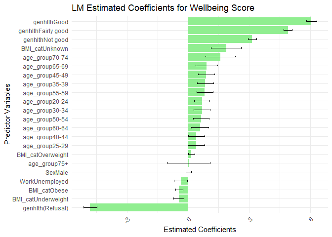

# Chi-Square Test

The Chi-Square test is a statistical test used to determine if there is a significant association between two categorical variables. It compares the observed frequencies of events to the expected frequencies under the assumption of independence (no association).

$$H_0: \text{The two variables are independent.}$$

Since BMI category, employment status, and general health status are categorical, we can also perform Chi-Square tests to check for independence between these variables.

The result will tell you whether BMI category and employment status/general health status are independent or related.

```
##
##  Pearson's Chi-squared test
##
## data:  table(WHS_selected$BMI_cat, WHS_selected$Work)
## X-squared = 3.3184, df = 4, p-value = 0.506
```

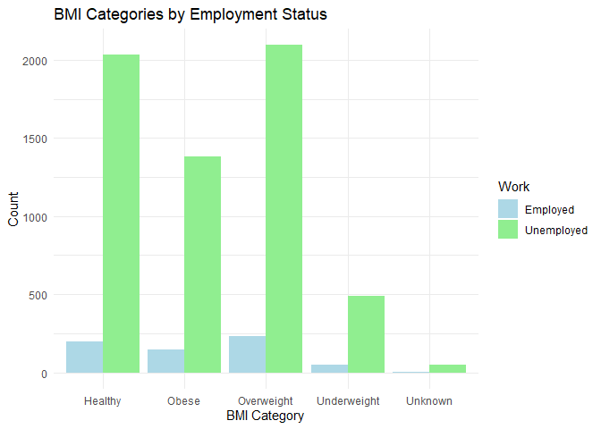

Chi-square test of BMI and general health status

```
##
##  Pearson's Chi-squared test
##
## data:  table(WHS_selected$BMI_cat, WHS_selected$genhlth)
## X-squared = 313.51, df = 16, p-value < 2.2e-16
```

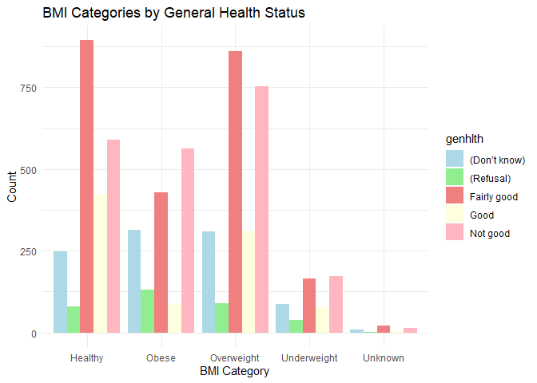

# ANOVA: Wellbeing by BMI Category

The results of ANOVA will tell you whether there are significant differences in wellbeing score across different BMI categories.

```
##               Df Sum Sq Mean Sq F value Pr(>F)
## BMI_cat        4   3591   897.8   26.02 <2e-16 ***
## Residuals   6669 230145    34.5
## ---
## Signif. codes:  0 '***' 0.001 '**' 0.01 '*' 0.05 '.' 0.1 ' ' 1
```

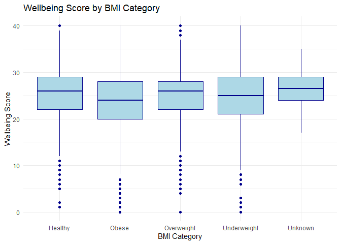